# Working with Geo-Data (part 2)

May 6, 2019

## A short introduction to data linkage with *dplyr*

## Data linkage with *dplyr*

Two datasets:

Particular matter: "pm" dataset

| city | pm_mg |
| --- | --- |
| Amman | 999 |
| Saltillo | 869 |
| Usak | 814 |
| The Bronx | 284 |
| Seoul | 129 |

GPS coordinates of cities: "city_coords" dataset

| city | lng | lat |
| --- | --- | --- |
| Amman | 31.9100 | 35.94800 |
| Saltillo | -100.9940 | 25.43400 |
| Berlin | 13.4020 | 52.52000 |
| Usak | 29.4030 | 38.67300 |
| New York | -73.9400 | 40.60000 |
| Seoul | 126.9838 | 37.53626 |

- to combine these datasets, the "city" column might be used as identifier for matching
- not all cities in "pm" also appear in "city_coords" and vice versa

## Join operations

pm

| city | pm_mg |
| --- | --- |
| Amman | 999 |
| Saltillo | 869 |
| Usak | 814 |
| The Bronx | 284 |
| Seoul | 129 |

city_coords

| city | lng | lat |
| --- | --- | --- |
| Amman | 31.9100 | 35.94800 |
| Saltillo | -100.9940 | 25.43400 |
| Berlin | 13.4020 | 52.52000 |
| Usak | 29.4030 | 38.67300 |
| New York | -73.9400 | 40.60000 |
| Seoul | 126.9838 | 37.53626 |

Datasets can also be joined with `merge`, but I find *dplyr* easier to use.

`left_join(a, b, by = <criterion>)`: **always retains rows on the "left side"** and fills up non-matching rows with *NA*s.

```r
library(dplyr)
left_join(pm, city_coords, by = 'city')
```

```
##        city pm_mg       lng      lat
## 1     Amman   999   31.9100 35.94800
## 2  Saltillo   869 -100.9940 25.43400
## 3      Usak   814   29.4030 38.67300
## 4 The Bronx   284        NA       NA
## 5     Seoul   129  126.9838 37.53626
```

## Join operations

pm

| city | pm_mg |
| --- | --- |
| Amman | 999 |
| Saltillo | 869 |
| Usak | 814 |
| The Bronx | 284 |
| Seoul | 129 |

city_coords

| city | lng | lat |
| --- | --- | --- |
| Amman | 31.9100 | 35.94800 |
| Saltillo | -100.9940 | 25.43400 |
| Berlin | 13.4020 | 52.52000 |
| Usak | 29.4030 | 38.67300 |
| New York | -73.9400 | 40.60000 |
| Seoul | 126.9838 | 37.53626 |

`right_join(a, b, by = <criterion>)`: **always retains rows on the "right side"** and fills up non-matching rows with *NA*s. **How many rows do you expect for a right join between `pm` and `city_coords`? How many of them will contain an *NA* value?**

```r
right_join(pm, city_coords, by = 'city')
```

```
##       city pm_mg       lng      lat
## 1    Amman   999   31.9100 35.94800
## 2 Saltillo   869 -100.9940 25.43400
## 3   Berlin    NA   13.4020 52.52000
## 4     Usak   814   29.4030 38.67300
## 5 New York    NA  -73.9400 40.60000
## 6    Seoul   129  126.9838 37.53626
```

## Join operations

pm

| city | pm_mg |
| --- | --- |
| Amman | 999 |
| Saltillo | 869 |
| Usak | 814 |
| The Bronx | 284 |
| Seoul | 129 |

city_coords

| city | lng | lat |
| --- | --- | --- |
| Amman | 31.9100 | 35.94800 |
| Saltillo | -100.9940 | 25.43400 |
| Berlin | 13.4020 | 52.52000 |
| Usak | 29.4030 | 38.67300 |
| New York | -73.9400 | 40.60000 |
| Seoul | 126.9838 | 37.53626 |

`inner_join(a, b, by = <criterion>)`: **only retains rows that match on both sides.**

How many rows do you expect for an inner join between `pm` and `city_coords`?

```r
inner_join(pm, city_coords, by = 'city')
```

```
##       city pm_mg       lng      lat
## 1    Amman   999   31.9100 35.94800
## 2 Saltillo   869 -100.9940 25.43400
## 3     Usak   814   29.4030 38.67300
## 4    Seoul   129  126.9838 37.53626
```

## Combining data and making a *choropleth map*

## What is a *choropleth map*?

In a *choropleth map*, regions are shaded according to the measurement of some variable, e.g.:

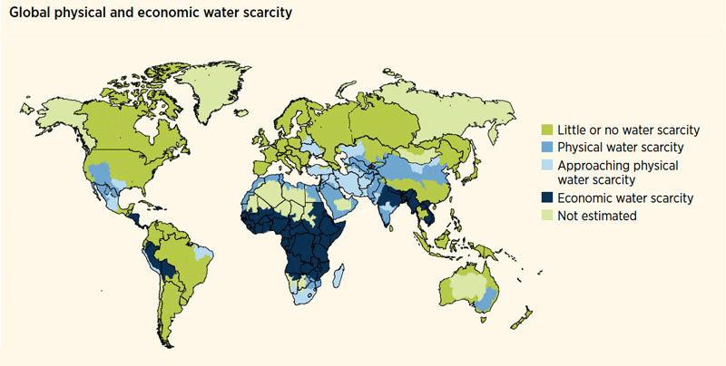

source: [United Nations, "Water for life action"](https://www.un.org/waterforlifedecade/scarcity.shtml)

## Making a choropleth map

- data downloaded from the Berlin Senate Dept. for Urban Dev. and Housing via [FIS Broker](https://fbinter.stadt-berlin.de/fb/index.jsp)
- includes indicators for monitoring of social development (*"Monitoring Soziale Stadtentwicklung 2017"*):

```r
bln_sozind <- read_sf('excercises/data/bln_plr_sozind.geojson')
head(bln_sozind)
```

```
## Simple feature collection with 6 features and 10 fields
## geometry type:  MULTIPOLYGON
## dimension:      XY
## bbox:           xmin: 386668.2 ymin: 5817761 xmax: 390764.3 ymax: 5820432
## epsg (SRID):    25833
## proj4string:    +proj=utm +zone=33 +ellps=GRS80 +towgs84=0,0,0,0,0,0,0 +units=m +no_defs
## # A tibble: 6 x 11
##   PLANNAME EW2016 STATUS1 STATUS2 STATUS3 STATUS4 DYNAMO1 DYNAMO2 DYNAMO3
##   <chr>    <chr>    <dbl>   <dbl>   <dbl>   <dbl>   <dbl>   <dbl>   <dbl>
## 1 Stülers… 3114      4.98    1.52    8.16   20.5    -0.19    0.14   -0.42
## 2 Großer … 192      NA      NA      NA      NA      NA      NA      NA
## 3 Lützows… 5518      6.83    2.08   17.7    34.3    -0.5    -0.03   -0.8
## 4 Körners… 4704      6.27    1.49   20.7    45.9    -1.33   -0.76   -1.66
## 5 Nördlic… 1135      2.06    0       1.5     3.55   -0.77   -0.74   -0.42
## 6 Wilhelm… 2190      3.64    0.89    8.45   27.3    -1.23   -0.59    0.13
## # … with 2 more variables: DYNAMO4 <dbl>, geometry <MULTIPOLYGON [m]>
```

## Making a choropleth map

```
## Simple feature collection with 3 features and 2 fields
## geometry type:  MULTIPOLYGON
## dimension:      XY
## bbox:           xmin: 386668.2 ymin: 5817875 xmax: 389894.1 ymax: 5820432
## epsg (SRID):    25833
## proj4string:    +proj=utm +zone=33 +ellps=GRS80 +towgs84=0,0,0,0,0,0,0 +units=m +no_defs
## # A tibble: 3 x 3
##   PLANNAME      STATUS4                                            geometry
##   <chr>           <dbl>                                  <MULTIPOLYGON [m]>
## 1 Stülerstraße     20.5 (((387256.6 5818552, 387258.6 5818545, 387261.3 58…
## 2 Großer Tierg…    NA   (((386767.5 5819393, 386767.3 5819393, 386767.1 58…
## 3 Lützowstraße     34.3 (((387952.6 5818275, 387974.2 5818265, 387994.8 58…
```

- source: FIS Broker, *"Monitoring Soziale Stadtentwicklung 2017"*¹
- aim: visualize spatial distrib. of variable **`STATUS4` – child poverty rate in percent²**
- dataset is already a **spatial dataset** containing geo-data in `geometry` column

¹ Note that the FIS-Broker website is kind of awkward to use and you can't link directly to dataset, but you have to search for the mentioned keywords.  
² Portion of children under 15 living in household that obtains social support ("Hartz IV")

## Making a choropleth map

Directly plotting the map with fill color depending on `STATUS4`:

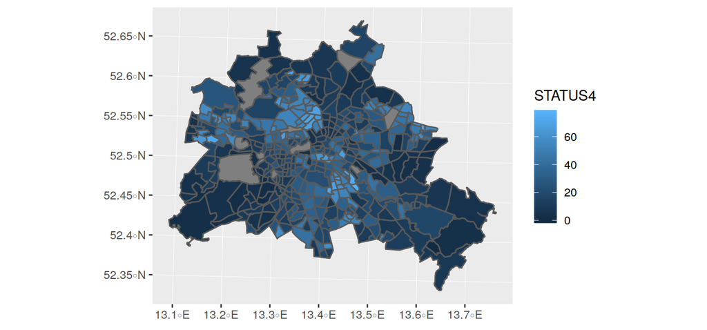

```r
ggplot() + geom_sf(aes(fill = STATUS4), data = bln_sozind)
```

Problem: `STATUS4` is continuous and so is the color scale. For choropleth maps, discrete ranges are better for discerning the colors.

## Making a choropleth map

Put the percentages into 5 discrete bins, change the color palette, adjust the appearance:

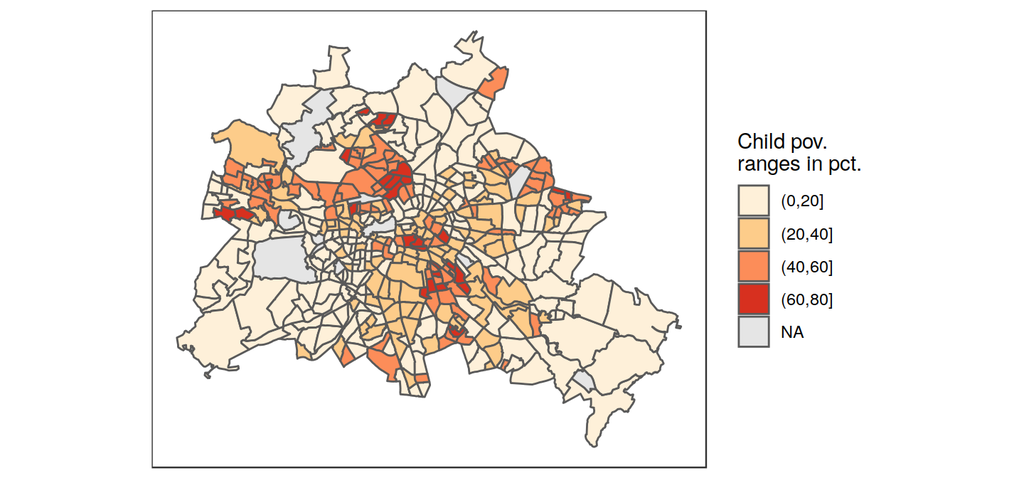

```r
bln_sozind$child_pov_bins <- cut(bln_sozind$STATUS4, seq(0, 100, by = 20))
ggplot() + geom_sf(aes(fill = child_pov_bins), data = bln_sozind) +
    scale_fill_brewer(palette = 'OrRd', na.value = "grey90",
                      guide = guide_legend(title = 'Child pov.\nranges in pct.')) +
    coord_sf(datum = NA) +  # disable lines ("graticules") in the background
    theme_bw() + theme(axis.text = element_blank(), axis.title = element_blank(),
                       axis.ticks = element_blank())
```

## Combining data

Most of the time, you have at least two datasets: one containing the measurement(s) you want to show, the other containing the geo-data.

Example dataset: [People at risk of poverty or social exclusion by NUTS 2 regions (*tgs00107*)](https://ec.europa.eu/eurostat/web/regions/data/main-tables) from Eurostat.

```r
pov_risk <- read.csv('excercises/data/tgs00107_pov_risk_nuts2.csv',
                     stringsAsFactors = FALSE)
pov_risk$risk_pct_bins <- cut(pov_risk$risk_pct, seq(0, 100, by = 10))

pov_risk_2016 <- filter(pov_risk, year == 2016)   # 2016 has fewest NAs
head(pov_risk_2016)
```

```
##   nuts year risk_pct risk_pct_bins
## 1   AT 2016     18.0       (10,20]
## 2 AT11 2016     15.1       (10,20]
## 3 AT12 2016     13.0       (10,20]
## 4 AT13 2016     26.0       (20,30]
## 5 AT21 2016     16.3       (10,20]
## 6 AT22 2016     18.4       (10,20]
```

## Combining data

We load the [GeoJSON dataset for NUTS level-2 regions provided by Eurostat](https://github.com/eurostat/Nuts2json):

```r
nutsrg2 <- read_sf('excercises/data/nutsrg_2.json')
st_crs(nutsrg2) <- 3857  # set the correct CRS
head(nutsrg2)
```

```
## Simple feature collection with 6 features and 2 fields
## geometry type:  MULTIPOLYGON
## dimension:      XY
## bbox:           xmin: 1347007 ymin: 4105701 xmax: 3847132 ymax: 6631069
## epsg (SRID):    3857
## proj4string:    +proj=merc +a=6378137 +b=6378137 +lat_ts=0.0 +lon_0=0.0 +x_0=0.0 +y_0=0 +k=1.0 +units=m +nadgrids=@null +wktext +no_defs
## # A tibble: 6 x 3
##   id    na                                                         geometry
##   <chr> <chr>                                            <MULTIPOLYGON [m]>
## 1 CY00  Κύπρος      (((3592720 4172836, 3594320 4178301, 3607520 4169324, …
## 2 CZ01  Praha       (((1588619 6463231, 1592220 6468696, 1617821 6476893, …
## 3 CZ02  Střední Če… (((1686224 6537392, 1685024 6526853, 1686624 6506167, …
## 4 CZ03  Jihozápad   (((1492615 6461670, 1536217 6432006, 1539017 6395706, …
## 5 CZ04  Severozápad (((1612621 6534270, 1600220 6515144, 1520216 6485089, …
## 6 CZ05  Severových… (((1729426 6582279, 1758628 6576034, 1786629 6556127, …
```

## Combining data

Both datasets contain a NUTS level-2 identifier so we can join them:

```r
pov_risk_2016_geo <- left_join(nutsrg2, pov_risk_2016, by = c('id' = 'nuts'))
head(pov_risk_2016_geo)
```

```
## Simple feature collection with 6 features and 5 fields
## geometry type:  MULTIPOLYGON
## dimension:      XY
## bbox:           xmin: 1347007 ymin: 4105701 xmax: 3847132 ymax: 6631069
## epsg (SRID):    3857
## proj4string:    +proj=merc +a=6378137 +b=6378137 +lat_ts=0.0 +lon_0=0.0 +x_0=0.0 +y_0=0 +k=1.0 +units=m +nadgrids=@null +wktext +no_defs
## # A tibble: 6 x 6
##   id    na      year risk_pct risk_pct_bins                        geometry
##   <chr> <chr>  <int>    <dbl> <fct>                      <MULTIPOLYGON [m]>
## 1 CY00  Κύπρος    NA     NA   <NA>          (((3592720 4172836, 3594320 41…
## 2 CZ01  Praha   2016     10.1 (10,20]       (((1588619 6463231, 1592220 64…
## 3 CZ02  Střed…  2016     10.3 (10,20]       (((1686224 6537392, 1685024 65…
## 4 CZ03  Jihoz…  2016     10   (0,10]        (((1492615 6461670, 1536217 64…
## 5 CZ04  Sever…  2016     19.5 (10,20]       (((1612621 6534270, 1600220 65…
## 6 CZ05  Sever…  2016     11.7 (10,20]       (((1729426 6582279, 1758628 65…
```

## Plotting the combined data

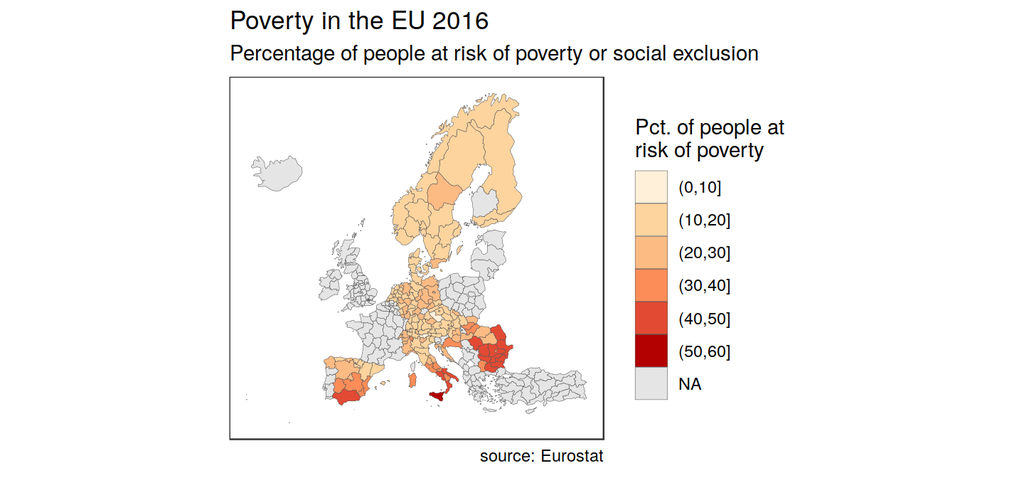

```r
(eu_pov_plt <- ggplot() + geom_sf(aes(fill = risk_pct_bins),
                                  data = pov_risk_2016_geo, size = 0.1) +
    scale_fill_brewer(palette = 'OrRd', na.value = "grey90",
                      guide = guide_legend(title = 'Pct. of people at\nrisk of poverty')) +
    labs(title = 'Poverty in the EU 2016',
         subtitle = 'Percentage of people at risk of poverty or social exclusion',
         caption = 'source: Eurostat') +
    coord_sf(datum = NA) +  # disable lines ("graticules") in the background
    theme_bw() + theme(axis.text = element_blank(), axis.title = element_blank(),
                       axis.ticks = element_blank()))
```

## Plotting the combined data

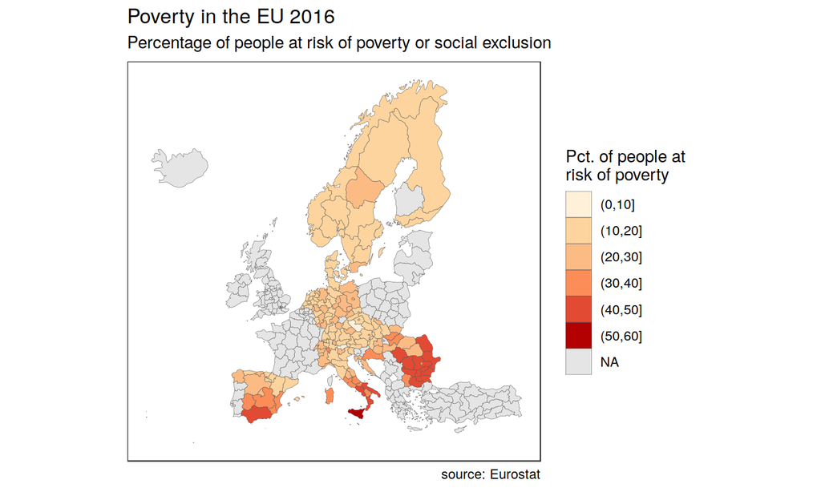

## Visualizing spatio-temporal data

If you also have a time-dimension in your data that you want to show, there are several options:

- using *small multiples* via ggplot facetting
- using animations via `gganimate`
- making an interactive map (e.g. with a "time slider")

## Visualizing spatio-temporal data

*Small multiples:* Dataset with time-related variable; plotted with facets (e.g. `facet_wrap()`)

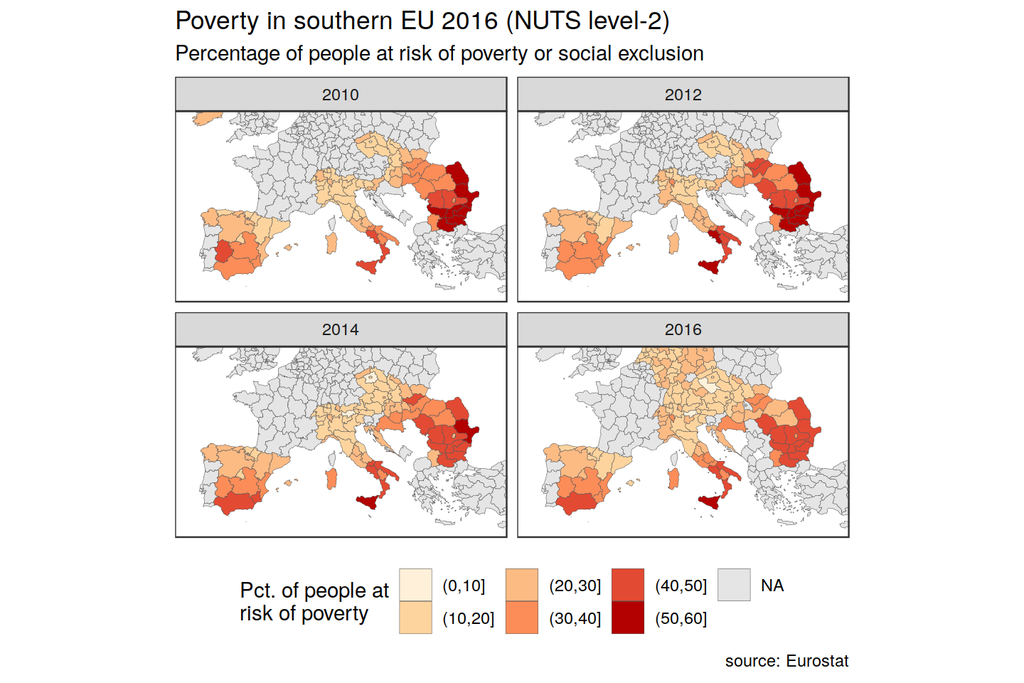

## Visualizing spatio-temporal data

Animations: Use `gganimate` for time-lapse plot animations.

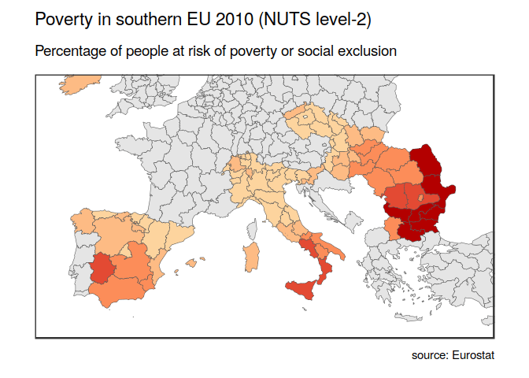

## Visualizing spatio-temporal data

- interactive plots (e.g. with a "time-slider") are harder to do
- interactive maps can be made in R with packages [leaflet](https://cran.r-project.org/web/packages/leaflet/index.html) or [Shiny](http://shiny.rstudio.com/)
- more sophisticated maps may require lots of programming effort

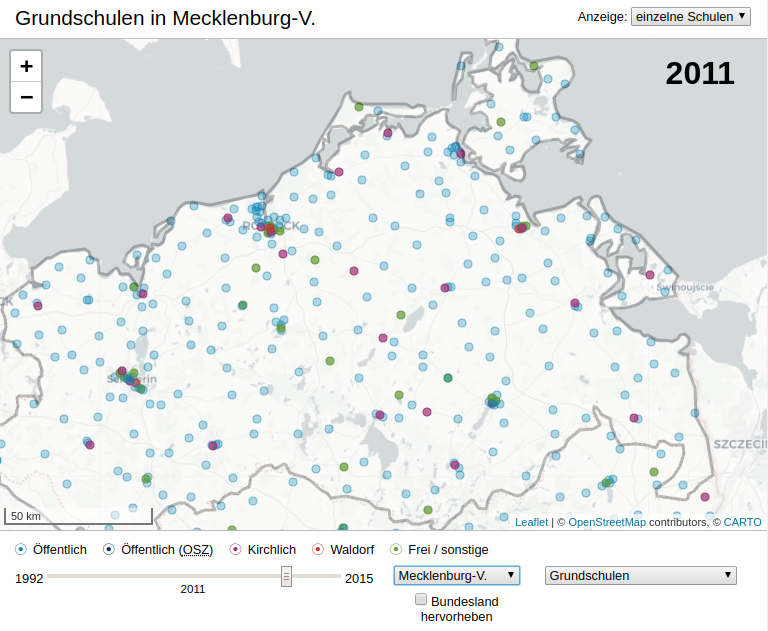

[Helbig, Konrad, Nikolai 2018 / https://schulenkarte.wzb.eu](https://schulenkarte.wzb.eu)

## Geocoding and reverse geocoding via Google Maps API

## What is geocoding?

**Geocoding** is the process of finding the geographic coordinates (longitude, latitude) for a specific query term (a full address, a postal code, a city name etc.).

- *Reichpietschufer 50, 10785 Berlin* → `13.36509, 52.50640`
- *cute cat cafe new york* → `-73.896916, 40.706934`

**Reverse geocoding** tries to map a set of geographic coordinates to a place name / address.

- `13.36509, 52.50640` → *Reichpietschufer 50, 10785 Berlin*

## Getting access

The [Google Maps API](https://cloud.google.com/maps-platform/) is a web service that allows programmatic geocoding or reverse geocoding (among other things). But simply, this means:

- you send a list of queries (e.g. addresses) to a Google server
- the server responds with a list of geo-coordinates

As of June 2018, the Maps API is part of Google's "Could Platform". This requires you to have:

1. A Google account (surprise!).
2. Start a [Google Cloud Platform (GCP)](https://cloud.google.com/) free trial (valid for one year).
3. Register for billing (they want your credit card).  
   They promise not to charge it after the end of the free trial…

Inside GCP, you can go to *APIs & Services > Credentials* to get your API key.

## Using *ggmap* for geocoding

You need to install the package *ggmap*, at least of version 2.7.

```r
library(ggmap)

# provide the Google Cloud API key here:
register_google(key = google_cloud_api_key)

places <- c('Berlin', 'Leipzig', '10317, Deutschland',
            'Reichpietschufer 50, 10785 Berlin')
#place_coords <- geocode(places) %>% mutate(place = places)
#place_coords
```

## Reverse geocoding

Take the WZB's geo-coordinates and see if we can find the address to it:

```r
# first longitude, then latitude
#revgeocode(c(13.36509, 52.50640))
```

Social media posts or digital photos often contain geo-coordinates that you may want to "reverse geocode".

## Making plots publication-ready

## Geographic coordinate systems and projections

EPSG

## Setting the display window

## Finding centroids of regions

## Labelling regions

## Labelling regions without occlusion

- coord_sf / st_crop
- labels:
- st_centroid
- col_bind

## Further reading

- sf vignette
- https://cran.r-project.org/web/views/Spatial.html
- https://geocompr.robinlovelace.net/
- ggplot2